# Exámen1

Maria Fernanda Gómez Flores

2026-10-01

# Problema 1

## a)

```r
library(quantmod)
library(moments)
library(tseries)
ticker <- "VOLARA.MX"
getSymbols(ticker, src="yahoo", from="2023-01-01", to="2025-01-01")
```

```
## [1] "VOLARA.MX"
```

```r
precio <- na.omit(Ad(get(ticker)))
```

```r
first(index(precio))
```

```
## [1] "2023-01-02"
```

```r
last(index(precio))
```

```
## [1] "2024-12-31"
```

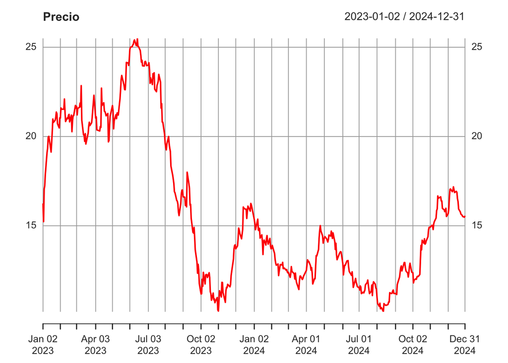

```r
plot(precio, main="Precio", col="red")
```

## b)

```r
log_precio <- log(precio)
simple_rend <- dailyReturn(precio, type="arithmetic")
log_rend <- dailyReturn(precio, type="log")
head(cbind(simple_rend, log_rend, log_precio))
```

```
##            daily.returns daily.returns.1 VOLARA.MX.Adjusted
## 2023-01-02    0.00000000      0.00000000           2.788093
## 2023-01-03   -0.06276926     -0.06482577           2.723267
## 2023-01-04    0.11950097      0.11288302           2.836150
## 2023-01-05    0.01114373      0.01108209           2.847232
## 2023-01-06    0.03712293      0.03645047           2.883683
## 2023-01-09    0.06879203      0.06652907           2.950212
```

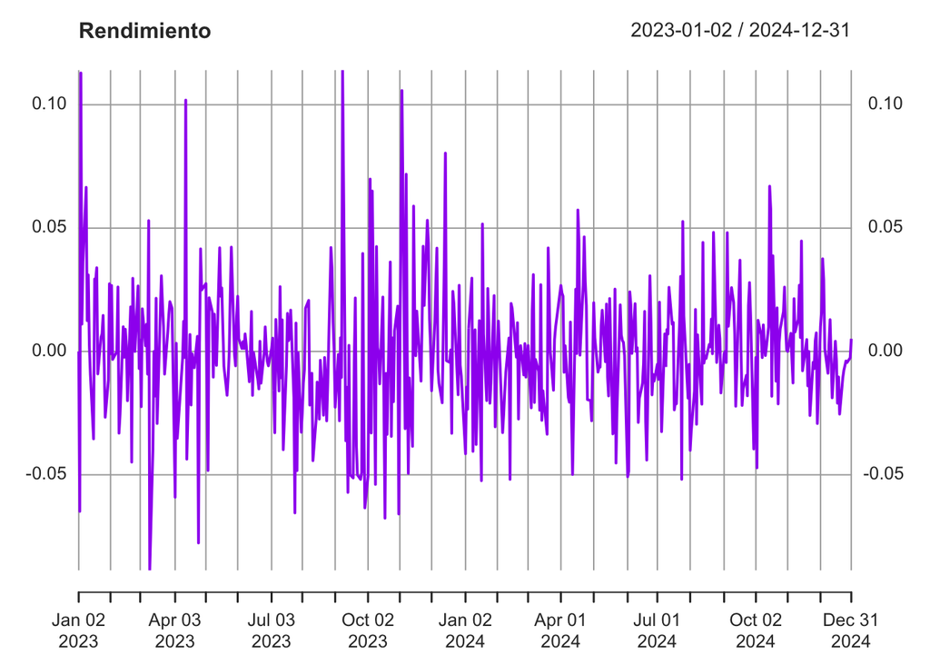

```r
plot(log_rend, n=100, main="Rendimiento", col="purple")
```

## c)

```r
r <- mean(log_rend)
R <- mean(simple_rend)
sigma_log <- sd(log_rend)
mean_log <- r
sigma_log
```

```
## [1] 0.02693011
```

```r
mean_log
```

```
## [1] -8.643299e-05
```

```r
dias_cot <- 252
sigma_anual <- sigma_log*sqrt(dias_cot)
sigma_anual
```

```
## [1] 0.4275022
```

```r
sigma_log
```

```
## [1] 0.02693011
```

```r
mu_log_anual <-dias_cot*mean_log
mu_log_anual
```

```
## [1] -0.02178111
```

```r
mu_gbm_anual <- mu_log_anual+0.5*sigma_anual^2
mu_gbm_anual
```

```
## [1] 0.06959796
```

```r
mean_simple_anual <- R*dias_cot
mean_simple_anual
```

```
## [1] 0.06974795
```

Media diaria de los log-rendimientos -8.6432994^{-5} Desviacion estandar diaria0.0269301 Volatilidad anual 0.4275022 Rendimiento anual compatible con GBM 0.069598

## d) Interpretacion

Porque si solo multiplico el rendimiento promedio por 252 me da el rendimiento anual del log del precio pero ese no es exactamente el mu que se usa en el GBM para sacar el mu que si usamos en el GBM se le tiene que sumar el ajuste de la volatilidad mu = rendimiento anual del log + 0.5*sigma^2

```r
So <- as.numeric(last(precio))
mu <- mu_gbm_anual
sigma <- sigma_anual
So
```

```
## [1] 15.56
```

```r
mu
```

```
## [1] 0.06959796
```

```r
sigma
```

```
## [1] 0.4275022
```

# Problema 2

```r
So <- as.numeric(last(precio))
mu <- mu_gbm_anual
sigma <- sigma_anual
So
```

```
## [1] 15.56
```

```r
mu
```

```
## [1] 0.06959796
```

```r
sigma
```

```
## [1] 0.4275022
```

## a)

```r
dt_25d <- 25/dias_cot

set.seed(123)

z <- rnorm(100000, mean = 0, sd=1)

St_25d <- So*exp((mu-.5*sigma^2)*dt_25d+sigma*sqrt(dt_25d)*z)

mean(St_25d)
```

```
## [1] 15.66976
```

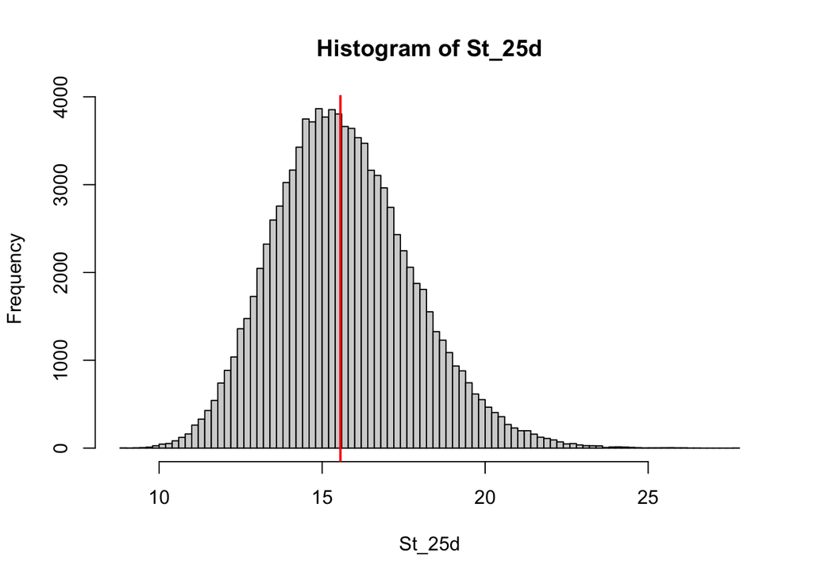

```r
hist(St_25d, n=100)
abline(v=So, col="red", lwd=2)
```

## b)

```r
prob_caida <- mean(St_25d<.95*So)

prob_caida
```

```
## [1] 0.35751
```

```r
prob_caida*100
```

```
## [1] 35.751
```

La probabilidad de que el precio caiga mas de 5% en 25 dias es de 35.751%.

## c)

```r
prob_caida>.10
```

```
## [1] TRUE
```

si se activa

## d)

```r
media_teo <- So*exp(mu*dt_25d)

media_emp <- mean(St_25d)

media_teo
```

```
## [1] 15.66781
```

```r
media_emp
```

```
## [1] 15.66976
```

```r
sqrt((media_emp-media_teo)^2)
```

```
## [1] 0.001956722
```

## e)

```r
dt_105d <- 105/dias_cot

set.seed(123)

z <- rnorm(100000, mean = 0, sd=1)
```

```r
dSt <- mu*So*dt_105d+sigma*So*sqrt(dt_105d)*z

St_apro <- So+dSt
```

```r
prob_apro <- mean(St_apro>1.04*So)

prob_apro
```

```
## [1] 0.48408
```

```r
St_exacta <- So*exp((mu-.5*sigma^2)*dt_105d+sigma*sqrt(dt_105d)*z)

prob_exacta <- mean(St_exacta>1.04*So)

prob_exacta
```

```
## [1] 0.43136
```

```r
prob_apro*100
```

```
## [1] 48.408
```

```r
prob_exacta*100
```

```
## [1] 43.136
```

## f)

```r
sqrt((prob_apro-prob_exacta)^2)
```

```
## [1] 0.05272
```

La solucion exacta del GBM es la que garantiza precios positivos porque usa una exponenciall a aproximacion con dS no los garantiza.

# Problema 3

```r
So_A <- 210
So_B <- 130
So_C <- 110

mu_A <- .11
mu_B <- .09
mu_C <- .20

sigma_A <- .28
sigma_B <- .42
sigma_C <- .52

T <- 1
```

## a)

```r
V0 <- 110*So_A+160*So_B+170*So_C

V0
```

```
## [1] 62600
```

## b)

```r
set.seed(123)

zA <- rnorm(100000, mean = 0, sd=1)
zB <- rnorm(100000, mean = 0, sd=1)
zC <- rnorm(100000, mean = 0, sd=1)
```

```r
St_A <- So_A*exp((mu_A-.5*sigma_A^2)*T+sigma_A*sqrt(T)*zA)

St_B <- So_B*exp((mu_B-.5*sigma_B^2)*T+sigma_B*sqrt(T)*zB)

St_C <- So_C*exp((mu_C-.5*sigma_C^2)*T+sigma_C*sqrt(T)*zC)
```

```r
Vt <- 110*St_A+160*St_B+170*St_C

head(Vt)
```

```
## [1] 67672.45 81240.70 67722.42 61629.58 63331.22 94780.40
```

## c)

```r
media_port <- mean(Vt)

media_port
```

```
## [1] 71456.33
```

```r
prob_perdida <- mean(Vt<V0-10000)

prob_perdida
```

```
## [1] 0.12173
```

```r
prob_perdida*100
```

```
## [1] 12.173
```

## d)

```r
prob_perdida<=.22
```

```
## [1] TRUE
```

se conserva el portafolio porque la probabilidad de perder mas de 10000 es menor o igual a 22% si usara el mismo vector de shocks para los 3 activos ya no serian independientes porque todos tendrian el mismo shock al mismo tiempo y eso cambiaria el riesgo del portafolio